# R Notebook: AIAG Attribute MSA/GRR Example

Cliff Long

# LOAD PACKAGES

```r
# general
library(here)
library(readxl)
library(janitor)
library(dplyr)
library(tidyr)
library(writexl)
library(irr)
library(ggplot2)
library(scales)
library(purrr)
library(broom)
library(stringr)
library(sessioninfo)
library(pander)

# for confusion matrix and misclassification rate
library(caret)
library(ISLR)
library(InformationValue) # package retired
```

# CITATION

Citation for R to include in report:

```r
x_cite <- citation()
print(x_cite, style = "text")
```

```
## R Core Team (2026). _R: A Language and Environment for Statistical
## Computing_. R Foundation for Statistical Computing, Vienna, Austria.
## doi:10.32614/R.manuals <https://doi.org/10.32614/R.manuals>.
## <https://www.R-project.org/>.
```

Session info:

```r
s_info <- sessionInfo()

cat(s_info$R.version$version.string)
```

R version 4.6.0 (2026-04-24 ucrt)

```r
cat("\n \n Base Packages \n")
```

Base Packages

```r
cat(s_info$basePkgs)
```

stats graphics grDevices utils datasets methods base

```r
cat("\n \n Other Packages \n")
```

Other Packages

```r
cat(names(s_info$otherPkgs))
```

InformationValue ISLR caret lattice pander sessioninfo stringr broom purrr scales ggplot2 irr lpSolve writexl tidyr dplyr janitor readxl here

# REFERENCES

- AIAG. AIAG Measurement Systems Analysis (MSA) Reference Manual. 4th ed., Chrysler, Ford, GM, 2010.
- Confusion Matrix. https://en.wikipedia.org/wiki/Confusion_matrix.
- “Fleiss’ Kappa.” Wikipedia, 25 Jan. 2024. Wikipedia, https://en.wikipedia.org/w/index.php?title=Fleiss%27_kappa&oldid=1198843670.
- Fleiss’ Kappa - Citizendium. https://en.citizendium.org/wiki/Fleiss%27_kappa. Accessed 29 Mar. 2024.

# LOAD DATA

```r
# initial load
fname <- "aiag_table_12_attr_msa.xlsx"
fsheet <- "aiag_table_12_attr_msa_long"
```

```r
# get data
d0 <- read_excel(path = here::here('data', fname), sheet = fsheet)
#glimpse(d0)
```

```r
# clean data variable names
d1 <- d0 %>% clean_names()
glimpse(d1)
```

```
## Rows: 450
## Columns: 8
## $ part       <dbl> 1, 2, 3, 4, 5, 6, 7, 8, 9, 10, 11, 12, 13, 14, 15, 16, 17, …
## $ appr_trial <chr> "A-1", "A-1", "A-1", "A-1", "A-1", "A-1", "A-1", "A-1", "A-…
## $ rating     <dbl> 1, 1, 0, 0, 0, 1, 1, 1, 0, 1, 1, 0, 1, 1, 1, 1, 1, 1, 1, 1,…
## $ reference  <dbl> 1, 1, 0, 0, 0, 1, 1, 1, 0, 1, 1, 0, 1, 1, 1, 1, 1, 1, 1, 1,…
## $ ref_value  <dbl> 0.476901, 0.590150, 0.576459, 0.566152, 0.570360, 0.544951,…
## $ partnum    <chr> "p_01", "p_02", "p_03", "p_04", "p_05", "p_06", "p_07", "p_…
## $ appr       <chr> "A", "A", "A", "A", "A", "A", "A", "A", "A", "A", "A", "A",…
## $ trial      <chr> "T1", "T1", "T1", "T1", "T1", "T1", "T1", "T1", "T1", "T1",…
```

# PREP DATA

The following assumes that the spreadsheet data is in LONG format (vs WIDE).

```r
### rename vars
# inspector (from appraiser)
# specimen (from part)
# true_state (from reference)
# trial
# one (add)
# trial_label (unused in this example, no blinding btwn trials)
# trial_result (from xxxxx)

d1a <- d1 %>%
  rename(inspector = appr,
         specimen = partnum,
         true_state = reference,
         trial = trial,
         trial_result = rating) %>%
  # created to be used for summing
  mutate(one = 1) %>%
  # remove redundant column after rename
  select(-one_of('part'))

glimpse(d1a)
```

```
## Rows: 450
## Columns: 8
## $ appr_trial   <chr> "A-1", "A-1", "A-1", "A-1", "A-1", "A-1", "A-1", "A-1", "…
## $ trial_result <dbl> 1, 1, 0, 0, 0, 1, 1, 1, 0, 1, 1, 0, 1, 1, 1, 1, 1, 1, 1, …
## $ true_state   <dbl> 1, 1, 0, 0, 0, 1, 1, 1, 0, 1, 1, 0, 1, 1, 1, 1, 1, 1, 1, …
## $ ref_value    <dbl> 0.476901, 0.590150, 0.576459, 0.566152, 0.570360, 0.54495…
## $ specimen     <chr> "p_01", "p_02", "p_03", "p_04", "p_05", "p_06", "p_07", "…
## $ inspector    <chr> "A", "A", "A", "A", "A", "A", "A", "A", "A", "A", "A", "A…
## $ trial        <chr> "T1", "T1", "T1", "T1", "T1", "T1", "T1", "T1", "T1", "T1…
## $ one          <dbl> 1, 1, 1, 1, 1, 1, 1, 1, 1, 1, 1, 1, 1, 1, 1, 1, 1, 1, 1, …
```

```r
head(d1a)
```

| appr_trial | trial_result | true_state | ref_value | specimen | inspector | trial | one |
| --- | --- | --- | --- | --- | --- | --- | --- |
| A-1 | 1 | 1 | 0.476901 | p_01 | A | T1 | 1 |
| A-1 | 1 | 1 | 0.590150 | p_02 | A | T1 | 1 |
| A-1 | 0 | 0 | 0.576459 | p_03 | A | T1 | 1 |
| A-1 | 0 | 0 | 0.566152 | p_04 | A | T1 | 1 |
| A-1 | 0 | 0 | 0.570360 | p_05 | A | T1 | 1 |
| A-1 | 1 | 1 | 0.544951 | p_06 | A | T1 | 1 |

```r
# quick look
with(d1a, table(trial, trial_result))
```

```
##      trial_result
## trial   0   1
##    T1  48 102
##    T2  49 101
##    T3  51  99
```

Create variable to indicate if appraiser result matches the True State.

```r
# pivot structure

# create variable to indicate if appraiser result matches true state
d2 <- d1a %>%
  mutate(trial_true_agree = if_else(trial_result == true_state, 1, 0))

glimpse(d2)
```

```
## Rows: 450
## Columns: 9
## $ appr_trial       <chr> "A-1", "A-1", "A-1", "A-1", "A-1", "A-1", "A-1", "A-1…
## $ trial_result     <dbl> 1, 1, 0, 0, 0, 1, 1, 1, 0, 1, 1, 0, 1, 1, 1, 1, 1, 1,…
## $ true_state       <dbl> 1, 1, 0, 0, 0, 1, 1, 1, 0, 1, 1, 0, 1, 1, 1, 1, 1, 1,…
## $ ref_value        <dbl> 0.476901, 0.590150, 0.576459, 0.566152, 0.570360, 0.5…
## $ specimen         <chr> "p_01", "p_02", "p_03", "p_04", "p_05", "p_06", "p_07…
## $ inspector        <chr> "A", "A", "A", "A", "A", "A", "A", "A", "A", "A", "A"…
## $ trial            <chr> "T1", "T1", "T1", "T1", "T1", "T1", "T1", "T1", "T1",…
## $ one              <dbl> 1, 1, 1, 1, 1, 1, 1, 1, 1, 1, 1, 1, 1, 1, 1, 1, 1, 1,…
## $ trial_true_agree <dbl> 1, 1, 1, 1, 1, 1, 1, 1, 1, 1, 1, 1, 1, 1, 1, 1, 1, 1,…
```

```r
# OPTIONAL
# export to excel to include in report
# write_xlsx(x = d2, path = "d2_out_4report.xlsx")
```

Quick verification by count.

```r
# quick verification
xtabs(~ inspector + specimen, data = d2)
```

```
##          specimen
## inspector p_01 p_02 p_03 p_04 p_05 p_06 p_07 p_08 p_09 p_10 p_11 p_12 p_13 p_14
##         A    3    3    3    3    3    3    3    3    3    3    3    3    3    3
##         B    3    3    3    3    3    3    3    3    3    3    3    3    3    3
##         C    3    3    3    3    3    3    3    3    3    3    3    3    3    3
##          specimen
## inspector p_15 p_16 p_17 p_18 p_19 p_20 p_21 p_22 p_23 p_24 p_25 p_26 p_27 p_28
##         A    3    3    3    3    3    3    3    3    3    3    3    3    3    3
##         B    3    3    3    3    3    3    3    3    3    3    3    3    3    3
##         C    3    3    3    3    3    3    3    3    3    3    3    3    3    3
##          specimen
## inspector p_29 p_30 p_31 p_32 p_33 p_34 p_35 p_36 p_37 p_38 p_39 p_40 p_41 p_42
##         A    3    3    3    3    3    3    3    3    3    3    3    3    3    3
##         B    3    3    3    3    3    3    3    3    3    3    3    3    3    3
##         C    3    3    3    3    3    3    3    3    3    3    3    3    3    3
##          specimen
## inspector p_43 p_44 p_45 p_46 p_47 p_48 p_49 p_50
##         A    3    3    3    3    3    3    3    3
##         B    3    3    3    3    3    3    3    3
##         C    3    3    3    3    3    3    3    3
```

# ANALYSIS - Kappa Method

```r
# prep data format for irr package

keep_wide <- c('trial', 'specimen', 'inspector', 'trial_result')
drop_cols <- c('trial', 'specimen')

d2w <- d2 %>%
  select(all_of(keep_wide)) %>%
  pivot_wider(names_from = 'inspector',
              values_from = 'trial_result') %>%
  select(-one_of(drop_cols))
```

```r
glimpse(d2w)
```

```
## Rows: 150
## Columns: 3
## $ A <dbl> 1, 1, 0, 0, 0, 1, 1, 1, 0, 1, 1, 0, 1, 1, 1, 1, 1, 1, 1, 1, 1, 0, 1,…
## $ B <dbl> 1, 1, 0, 0, 0, 1, 1, 1, 0, 1, 1, 0, 1, 1, 1, 1, 1, 1, 1, 1, 1, 0, 1,…
## $ C <dbl> 1, 1, 0, 0, 0, 1, 1, 1, 0, 1, 1, 0, 1, 1, 1, 1, 1, 1, 1, 1, 0, 1, 1,…
```

```r
head(d2w)
```

| A | B | C |
| --- | --- | --- |
| 1 | 1 | 1 |
| 1 | 1 | 1 |
| 0 | 0 | 0 |
| 0 | 0 | 0 |
| 0 | 0 | 0 |
| 1 | 1 | 1 |

### compare raters A and B

```r
d_ratings_AB <- d2w %>% select(all_of(c('A', 'B')))
(kappa2_AB <- kappa2(ratings = d_ratings_AB))
```

```
##  Cohen's Kappa for 2 Raters (Weights: unweighted)
##
##  Subjects = 150
##    Raters = 2
##     Kappa = 0.863
##
##         z = 10.6
##   p-value = 0
```

### compare raters A and C

```r
d_ratings_AC <- d2w %>% select(all_of(c('A', 'C')))
(kappa2_AC <- kappa2(ratings = d_ratings_AC))
```

```
##  Cohen's Kappa for 2 Raters (Weights: unweighted)
##
##  Subjects = 150
##    Raters = 2
##     Kappa = 0.776
##
##         z = 9.51
##   p-value = 0
```

### compare raters B and C

```r
d_ratings_BC <- d2w %>% select(all_of(c('B', 'C')))
(kappa2_BC <- kappa2(ratings = d_ratings_BC))
```

```
##  Cohen's Kappa for 2 Raters (Weights: unweighted)
##
##  Subjects = 150
##    Raters = 2
##     Kappa = 0.788
##
##         z = 9.67
##   p-value = 0
```

NOTE: matches the AIAG output page 129

## IRR: overall analysis Fleiss Kappa

Fleiss Kappa

```r
kappam.fleiss(d2w)
```

```
##  Fleiss' Kappa for m Raters
##
##  Subjects = 150
##    Raters = 3
##     Kappa = 0.809
##
##         z = 17.2
##   p-value = 0
```

Fleiss Kappa with detail

```r
kappam.fleiss(d2w, detail = TRUE)
```

```
##  Fleiss' Kappa for m Raters
##
##  Subjects = 150
##    Raters = 3
##     Kappa = 0.809
##
##         z = 17.2
##   p-value = 0
##
##    Kappa      z p.value
## 0  0.809 17.155   0.000
## 1  0.809 17.155   0.000
```

## IRR: overall analysis Lights Kappa

```r
kappam.light(d2w)
```

```
##  Light's Kappa for m Raters
##
##  Subjects = 150
##    Raters = 3
##     Kappa = 0.809
##
##         z = 5.85
##   p-value = 5.01e-09
```

# IRR: percent agreement among raters

Using the “irr” package and the “agree” function.

```r
irr::agree(d2w)
```

```
##  Percentage agreement (Tolerance=0)
##
##  Subjects = 150
##    Raters = 3
##   %-agree = 87.3
```

# ANALYSIS - agreement with standard

## agreement with standard - INTER-rater

```r
d2 %>%
  # add confidence intervals
  count(trial_true_agree) %>%
  mutate(prop = n / sum(n),
         lower = lapply(n, prop.test, n = sum(n)),
         upper = sapply(lower, function(x) x$conf.int[2]),
         lower = sapply(lower, function(x) x$conf.int[1])) %>%
  filter(trial_true_agree == 1) %>%
  pander()
```

| trial_true_agree | n | prop | lower | upper |
| --- | --- | --- | --- | --- |
| 1 | 422 | 0.9378 | 0.9103 | 0.9575 |

# EXPLORATORY-ONLY TABLES AND PLOTS

## agreement with standard - by inspector

```r
### prep data for plotting
d2_summary_byinsp <- d2 %>%
  group_by(inspector) %>%
  summarize(ct_agree = sum(trial_true_agree),
            total_obs = length(trial_true_agree),
            true_state = true_state[1]) %>%
  mutate(prop_correct = map2(ct_agree, total_obs, ~ prop.test(.x, .y, conf.level = 0.95) %>%
                               broom::tidy())) %>%
  unnest(prop_correct) %>%
  mutate(cross50 = case_when(conf.low <= 0.5 ~ 'below',
                             TRUE ~ 'above'))

pander(d2_summary_byinsp)
```

Table continues below

| inspector | ct_agree | total_obs | true_state | estimate | statistic |
| --- | --- | --- | --- | --- | --- |
| A | 142 | 150 | 1 | 0.9467 | 117.9 |
| B | 145 | 150 | 1 | 0.9667 | 128.8 |
| C | 135 | 150 | 1 | 0.9 | 94.41 |

Table continues below

| p.value | parameter | conf.low | conf.high | method |
| --- | --- | --- | --- | --- |
| 1.799e-27 | 1 | 0.8941 | 0.975 | 1-sample proportions test with continuity correction |
| 7.476e-30 | 1 | 0.9199 | 0.9877 | 1-sample proportions test with continuity correction |
| 2.569e-22 | 1 | 0.8377 | 0.941 | 1-sample proportions test with continuity correction |

| alternative | cross50 |
| --- | --- |
| two.sided | above |
| two.sided | above |
| two.sided | above |

```r
# glimpse(d2_summary_byinsp)
```

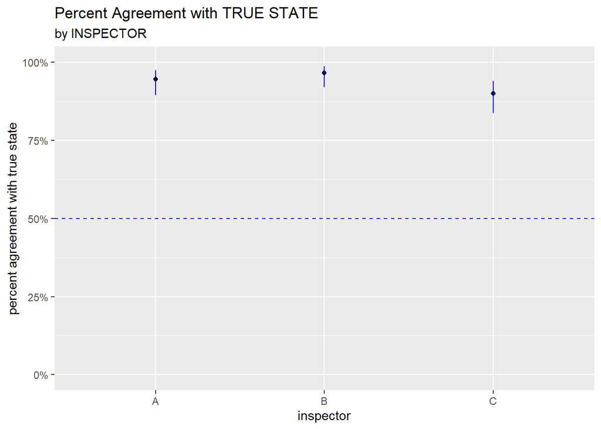

```r
### plot data
d2_summary_byinsp %>%
  # filter(trial_true_agree == 1) %>%
  ggplot(aes(x = inspector, y = estimate)) +
  geom_point() +
  geom_hline(yintercept = 0.5, linetype = 2, color = 'blue') +
  geom_segment(aes(x = inspector, xend = inspector, y = conf.low, yend = conf.high, color = cross50)) +
  ggtitle(label = "Percent Agreement with TRUE STATE",
          subtitle = "by INSPECTOR") +
  scale_y_continuous(labels = scales::percent, limits = c(0, 1)) +
  scale_color_manual(values=c("blue", "red", "#00B81F", "red")) +
  ylab("percent agreement with true state") +
  theme(legend.position = 'none') +
  NULL
```

## agreement with standard - by inspector and standard

```r
d2_summary_byinsp2 <- d2 %>%
  group_by(inspector, true_state) %>%
  summarize(ct_agree = sum(trial_true_agree),
            total_obs = length(trial_true_agree),
            true_state = true_state[1]) %>%
  mutate(prop_correct = map2(ct_agree, total_obs, ~ prop.test(.x, .y, conf.level = 0.95) %>%
                               broom::tidy())) %>%
  unnest(prop_correct) %>%
  mutate(cross50 = case_when(conf.low <= 0.5 ~ 'below',
                             TRUE ~ 'above'))
```

```
## `summarise()` has regrouped the output.
## ℹ Summaries were computed grouped by inspector and true_state.
## ℹ Output is grouped by inspector.
## ℹ Use `summarise(.groups = "drop_last")` to silence this message.
## ℹ Use `summarise(.by = c(inspector, true_state))` for per-operation grouping
##   (`?dplyr::dplyr_by`) instead.
```

```r
pander(d2_summary_byinsp2)
```

Table continues below

| inspector | true_state | ct_agree | total_obs | estimate | statistic |
| --- | --- | --- | --- | --- | --- |
| A | 0 | 45 | 48 | 0.9375 | 35.02 |
| A | 1 | 97 | 102 | 0.951 | 81.19 |
| B | 0 | 45 | 48 | 0.9375 | 35.02 |
| B | 1 | 100 | 102 | 0.9804 | 92.25 |
| C | 0 | 42 | 48 | 0.875 | 25.52 |
| C | 1 | 93 | 102 | 0.9118 | 67.54 |

Table continues below

| p.value | parameter | conf.low | conf.high | method |
| --- | --- | --- | --- | --- |
| 3.262e-09 | 1 | 0.8179 | 0.9837 | 1-sample proportions test with continuity correction |
| 2.054e-19 | 1 | 0.8839 | 0.9818 | 1-sample proportions test with continuity correction |
| 3.262e-09 | 1 | 0.8179 | 0.9837 | 1-sample proportions test with continuity correction |
| 7.658e-22 | 1 | 0.9241 | 0.9966 | 1-sample proportions test with continuity correction |
| 4.376e-07 | 1 | 0.7406 | 0.9481 | 1-sample proportions test with continuity correction |
| 2.065e-16 | 1 | 0.8348 | 0.9563 | 1-sample proportions test with continuity correction |

| alternative | cross50 |
| --- | --- |
| two.sided | above |
| two.sided | above |
| two.sided | above |
| two.sided | above |
| two.sided | above |
| two.sided | above |

```r
# d2_summary_byinsp2

# glimpse(d2_summary_byinsp2)
```

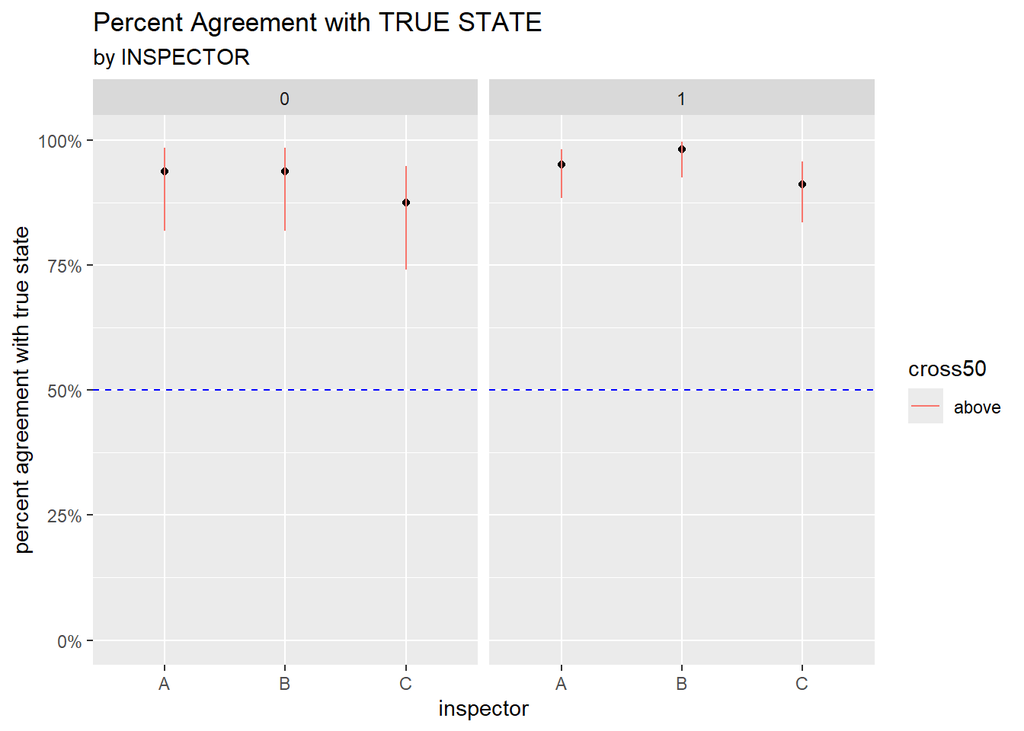

```r
### prep data for plotting
# glimpse(d2_summary_byinsp2)
### plot data
d2_summary_byinsp2 %>%
  # filter(trial_true_agree == 1) %>%
  ggplot(aes(x = inspector, y = estimate)) +
  geom_point() +
  geom_hline(yintercept = 0.5, linetype = 2, color = 'blue') +
  geom_segment(aes(x = inspector, xend = inspector, y = conf.low, yend = conf.high, color = cross50)) +
  ggtitle(label = "Percent Agreement with TRUE STATE",
          subtitle = "by INSPECTOR") +
  scale_y_continuous(labels = scales::percent, limits = c(0, 1)) +
  # scale_color_manual(values=c("blue", "red", "#00B81F", "red")) +
  ylab("percent agreement with true state") +
  # geom_point(aes(x = inspector, y = 0)) +
  # theme(legend.position='none') +
  facet_wrap(~ true_state) +
  NULL
```

## agreement with standard - by specimen (part)

https://stackoverflow.com/questions/50977337/calling-prop-test-function-in-r-with-dplyr

```r
# prep data for plotting
d2_summary_bypart <- d2 %>%
  group_by(specimen) %>%
  summarize(ct_agree = sum(trial_true_agree),
            total_obs = length(trial_true_agree),
            true_state = true_state[1]) %>%
  mutate(prop_correct = map2(ct_agree, total_obs, ~ prop.test(.x, .y, conf.level = 0.95) %>%
                               broom::tidy())) %>%
  unnest(prop_correct) %>%
  mutate(cross50 = case_when(conf.low <= 0.5 ~ 'below',
                             TRUE ~ 'above'))
pander(d2_summary_bypart)
```

Table continues below

| specimen | ct_agree | total_obs | true_state | estimate | statistic | p.value |
| --- | --- | --- | --- | --- | --- | --- |
| p_01 | 9 | 9 | 1 | 1 | 7.111 | 0.007661 |
| p_02 | 9 | 9 | 1 | 1 | 7.111 | 0.007661 |
| p_03 | 9 | 9 | 0 | 1 | 7.111 | 0.007661 |
| p_04 | 9 | 9 | 0 | 1 | 7.111 | 0.007661 |
| p_05 | 9 | 9 | 0 | 1 | 7.111 | 0.007661 |
| p_06 | 5 | 9 | 1 | 0.5556 | 0 | 1 |
| p_07 | 8 | 9 | 1 | 0.8889 | 4 | 0.0455 |
| p_08 | 9 | 9 | 1 | 1 | 7.111 | 0.007661 |
| p_09 | 9 | 9 | 0 | 1 | 7.111 | 0.007661 |
| p_10 | 9 | 9 | 1 | 1 | 7.111 | 0.007661 |
| p_11 | 9 | 9 | 1 | 1 | 7.111 | 0.007661 |
| p_12 | 8 | 9 | 0 | 0.8889 | 4 | 0.0455 |
| p_13 | 9 | 9 | 1 | 1 | 7.111 | 0.007661 |
| p_14 | 6 | 9 | 1 | 0.6667 | 0.4444 | 0.505 |
| p_15 | 9 | 9 | 1 | 1 | 7.111 | 0.007661 |
| p_16 | 9 | 9 | 1 | 1 | 7.111 | 0.007661 |
| p_17 | 9 | 9 | 1 | 1 | 7.111 | 0.007661 |
| p_18 | 9 | 9 | 1 | 1 | 7.111 | 0.007661 |
| p_19 | 9 | 9 | 1 | 1 | 7.111 | 0.007661 |
| p_20 | 9 | 9 | 1 | 1 | 7.111 | 0.007661 |
| p_21 | 5 | 9 | 1 | 0.5556 | 0 | 1 |
| p_22 | 5 | 9 | 0 | 0.5556 | 0 | 1 |
| p_23 | 9 | 9 | 1 | 1 | 7.111 | 0.007661 |
| p_24 | 9 | 9 | 1 | 1 | 7.111 | 0.007661 |
| p_25 | 9 | 9 | 0 | 1 | 7.111 | 0.007661 |
| p_26 | 7 | 9 | 0 | 0.7778 | 1.778 | 0.1824 |
| p_27 | 9 | 9 | 1 | 1 | 7.111 | 0.007661 |
| p_28 | 9 | 9 | 1 | 1 | 7.111 | 0.007661 |
| p_29 | 9 | 9 | 1 | 1 | 7.111 | 0.007661 |
| p_30 | 8 | 9 | 0 | 0.8889 | 4 | 0.0455 |
| p_31 | 9 | 9 | 1 | 1 | 7.111 | 0.007661 |
| p_32 | 9 | 9 | 1 | 1 | 7.111 | 0.007661 |
| p_33 | 9 | 9 | 1 | 1 | 7.111 | 0.007661 |
| p_34 | 5 | 9 | 0 | 0.5556 | 0 | 1 |
| p_35 | 9 | 9 | 1 | 1 | 7.111 | 0.007661 |
| p_36 | 7 | 9 | 1 | 0.7778 | 1.778 | 0.1824 |
| p_37 | 9 | 9 | 0 | 1 | 7.111 | 0.007661 |
| p_38 | 9 | 9 | 1 | 1 | 7.111 | 0.007661 |
| p_39 | 9 | 9 | 0 | 1 | 7.111 | 0.007661 |
| p_40 | 9 | 9 | 1 | 1 | 7.111 | 0.007661 |
| p_41 | 9 | 9 | 1 | 1 | 7.111 | 0.007661 |
| p_42 | 9 | 9 | 0 | 1 | 7.111 | 0.007661 |
| p_43 | 7 | 9 | 1 | 0.7778 | 1.778 | 0.1824 |
| p_44 | 9 | 9 | 1 | 1 | 7.111 | 0.007661 |
| p_45 | 9 | 9 | 0 | 1 | 7.111 | 0.007661 |
| p_46 | 9 | 9 | 1 | 1 | 7.111 | 0.007661 |
| p_47 | 9 | 9 | 1 | 1 | 7.111 | 0.007661 |
| p_48 | 9 | 9 | 0 | 1 | 7.111 | 0.007661 |
| p_49 | 9 | 9 | 1 | 1 | 7.111 | 0.007661 |
| p_50 | 9 | 9 | 0 | 1 | 7.111 | 0.007661 |

Table continues below

| parameter | conf.low | conf.high | method |
| --- | --- | --- | --- |
| 1 | 0.6288 | 1 | 1-sample proportions test with continuity correction |
| 1 | 0.6288 | 1 | 1-sample proportions test with continuity correction |
| 1 | 0.6288 | 1 | 1-sample proportions test with continuity correction |
| 1 | 0.6288 | 1 | 1-sample proportions test with continuity correction |
| 1 | 0.6288 | 1 | 1-sample proportions test with continuity correction |
| 1 | 0.2265 | 0.8466 | 1-sample proportions test with continuity correction |
| 1 | 0.5067 | 0.9942 | 1-sample proportions test with continuity correction |
| 1 | 0.6288 | 1 | 1-sample proportions test with continuity correction |
| 1 | 0.6288 | 1 | 1-sample proportions test with continuity correction |
| 1 | 0.6288 | 1 | 1-sample proportions test with continuity correction |
| 1 | 0.6288 | 1 | 1-sample proportions test with continuity correction |
| 1 | 0.5067 | 0.9942 | 1-sample proportions test with continuity correction |
| 1 | 0.6288 | 1 | 1-sample proportions test with continuity correction |
| 1 | 0.3092 | 0.9096 | 1-sample proportions test with continuity correction |
| 1 | 0.6288 | 1 | 1-sample proportions test with continuity correction |
| 1 | 0.6288 | 1 | 1-sample proportions test with continuity correction |
| 1 | 0.6288 | 1 | 1-sample proportions test with continuity correction |
| 1 | 0.6288 | 1 | 1-sample proportions test with continuity correction |
| 1 | 0.6288 | 1 | 1-sample proportions test with continuity correction |
| 1 | 0.6288 | 1 | 1-sample proportions test with continuity correction |
| 1 | 0.2265 | 0.8466 | 1-sample proportions test with continuity correction |
| 1 | 0.2265 | 0.8466 | 1-sample proportions test with continuity correction |
| 1 | 0.6288 | 1 | 1-sample proportions test with continuity correction |
| 1 | 0.6288 | 1 | 1-sample proportions test with continuity correction |
| 1 | 0.6288 | 1 | 1-sample proportions test with continuity correction |
| 1 | 0.4019 | 0.9605 | 1-sample proportions test with continuity correction |
| 1 | 0.6288 | 1 | 1-sample proportions test with continuity correction |
| 1 | 0.6288 | 1 | 1-sample proportions test with continuity correction |
| 1 | 0.6288 | 1 | 1-sample proportions test with continuity correction |
| 1 | 0.5067 | 0.9942 | 1-sample proportions test with continuity correction |
| 1 | 0.6288 | 1 | 1-sample proportions test with continuity correction |
| 1 | 0.6288 | 1 | 1-sample proportions test with continuity correction |
| 1 | 0.6288 | 1 | 1-sample proportions test with continuity correction |
| 1 | 0.2265 | 0.8466 | 1-sample proportions test with continuity correction |
| 1 | 0.6288 | 1 | 1-sample proportions test with continuity correction |
| 1 | 0.4019 | 0.9605 | 1-sample proportions test with continuity correction |
| 1 | 0.6288 | 1 | 1-sample proportions test with continuity correction |
| 1 | 0.6288 | 1 | 1-sample proportions test with continuity correction |
| 1 | 0.6288 | 1 | 1-sample proportions test with continuity correction |
| 1 | 0.6288 | 1 | 1-sample proportions test with continuity correction |
| 1 | 0.6288 | 1 | 1-sample proportions test with continuity correction |
| 1 | 0.6288 | 1 | 1-sample proportions test with continuity correction |
| 1 | 0.4019 | 0.9605 | 1-sample proportions test with continuity correction |
| 1 | 0.6288 | 1 | 1-sample proportions test with continuity correction |
| 1 | 0.6288 | 1 | 1-sample proportions test with continuity correction |
| 1 | 0.6288 | 1 | 1-sample proportions test with continuity correction |
| 1 | 0.6288 | 1 | 1-sample proportions test with continuity correction |
| 1 | 0.6288 | 1 | 1-sample proportions test with continuity correction |
| 1 | 0.6288 | 1 | 1-sample proportions test with continuity correction |
| 1 | 0.6288 | 1 | 1-sample proportions test with continuity correction |

| alternative | cross50 |
| --- | --- |
| two.sided | above |
| two.sided | above |
| two.sided | above |
| two.sided | above |
| two.sided | above |
| two.sided | below |
| two.sided | above |
| two.sided | above |
| two.sided | above |
| two.sided | above |
| two.sided | above |
| two.sided | above |
| two.sided | above |
| two.sided | below |
| two.sided | above |
| two.sided | above |
| two.sided | above |
| two.sided | above |
| two.sided | above |
| two.sided | above |
| two.sided | below |
| two.sided | below |
| two.sided | above |
| two.sided | above |
| two.sided | above |
| two.sided | below |
| two.sided | above |
| two.sided | above |
| two.sided | above |
| two.sided | above |
| two.sided | above |
| two.sided | above |
| two.sided | above |
| two.sided | below |
| two.sided | above |
| two.sided | below |
| two.sided | above |
| two.sided | above |
| two.sided | above |
| two.sided | above |
| two.sided | above |
| two.sided | above |
| two.sided | below |
| two.sided | above |
| two.sided | above |
| two.sided | above |
| two.sided | above |
| two.sided | above |
| two.sided | above |
| two.sided | above |

```r
#d2_summary_bypart
#glimpse(d2_summary_bypart)
```

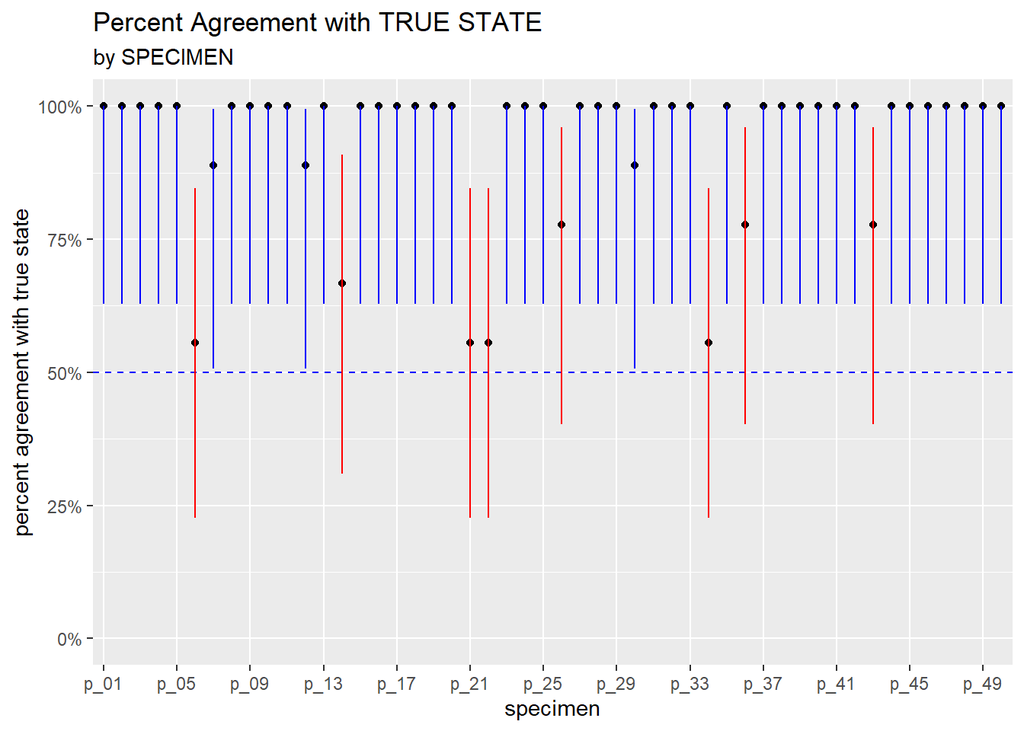

```r
# plot data
d2_summary_bypart %>%
  ggplot(aes(x = specimen, y = estimate)) +
  geom_point() +
  geom_hline(yintercept = 0.5, linetype = 2, color = 'blue') +
  geom_segment(aes(x = specimen, xend = specimen, y = conf.low, yend = conf.high, color = cross50)) +
  ggtitle(label = "Percent Agreement with TRUE STATE",
          subtitle = "by SPECIMEN") +
  scale_y_continuous(labels = scales::percent, limits = c(0, 1)) +
  scale_color_manual(values=c("blue", "red", "#00B81F", "red")) +
  ylab("percent agreement with true state") +
  #geom_point(aes(x = specimen, y = 0, color = true_state), alpha = 0.5) +
  theme(legend.position='none') +
  scale_x_discrete(breaks = function(x) x[seq(1, length(x), by = 4)]) +
  NULL
```

## agreement with standard - by true_state

```r
# prep data for plotting
d2_summary_bystate <- d2 %>%
  group_by(true_state) %>%
  summarize(ct_agree = sum(trial_true_agree),
            total_obs = length(trial_true_agree),
            true_state = true_state[1]) %>%
  mutate(prop_correct = map2(ct_agree, total_obs, ~ prop.test(.x, .y, conf.level = 0.95) %>%
                               broom::tidy())) %>%
  unnest(prop_correct) %>%
  mutate(cross50 = case_when(conf.low <= 0.5 ~ 'below',
                             TRUE ~ 'above')) %>%
  mutate(true_state_char = as.character(true_state))

pander(d2_summary_bystate)
```

Table continues below

| true_state | ct_agree | total_obs | estimate | statistic | p.value |
| --- | --- | --- | --- | --- | --- |
| 0 | 132 | 144 | 0.9167 | 98.34 | 3.523e-23 |
| 1 | 290 | 306 | 0.9477 | 243.6 | 6.588e-55 |

Table continues below

| parameter | conf.low | conf.high | method |
| --- | --- | --- | --- |
| 1 | 0.8558 | 0.9543 | 1-sample proportions test with continuity correction |
| 1 | 0.9148 | 0.9688 | 1-sample proportions test with continuity correction |

| alternative | cross50 | true_state_char |
| --- | --- | --- |
| two.sided | above | 0 |
| two.sided | above | 1 |

```r
# d2_summary_bystate
# glimpse(d2_summary_bystate)
```

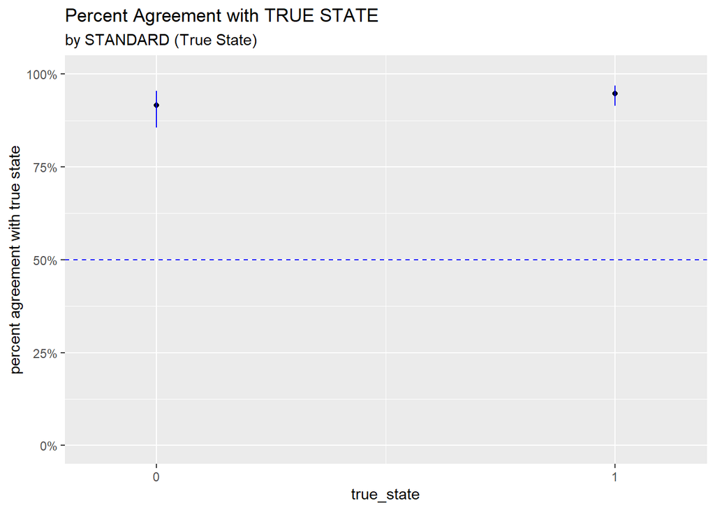

```r
# plot data
d2_summary_bystate %>%
  ggplot(aes(x = true_state, y = estimate)) +
  geom_point() +
  geom_hline(yintercept = 0.5, linetype = 2, color = 'blue') +
  geom_segment(aes(x = true_state, xend = true_state, y = conf.low, yend = conf.high, color = cross50)) +
  ggtitle(label = "Percent Agreement with TRUE STATE",
          subtitle = "by STANDARD (True State)") +
  scale_y_continuous(labels = scales::percent, limits = c(0, 1)) +
  scale_color_manual(values=c("blue", "red", "#00B81F", "red")) +
  ylab("percent agreement with true state") +
  #geom_point(aes(x = true_state, y = 0), alpha = 0.5) +
  theme(legend.position='none') +
  scale_x_continuous(breaks = c(0, 1), expand = 0.1) +
  NULL
```

## agreement with standard - by trial

https://stackoverflow.com/questions/50977337/calling-prop-test-function-in-r-with-dplyr

```r
# prep data for plotting
d2_summary_bytrial <- d2 %>%
  group_by(trial, true_state) %>%
  summarize(ct_agree = sum(trial_true_agree),
            total_obs = length(trial_true_agree),
            true_state = true_state[1]) %>%
  mutate(prop_correct = map2(ct_agree, total_obs, ~ prop.test(.x, .y, conf.level = 0.95) %>%
                               broom::tidy())) %>%
  unnest(prop_correct) %>%
  mutate(cross50 = case_when(conf.low <= 0.5 ~ 'below',
                             TRUE ~ 'above'))
```

```
## `summarise()` has regrouped the output.
## ℹ Summaries were computed grouped by trial and true_state.
## ℹ Output is grouped by trial.
## ℹ Use `summarise(.groups = "drop_last")` to silence this message.
## ℹ Use `summarise(.by = c(trial, true_state))` for per-operation grouping
##   (`?dplyr::dplyr_by`) instead.
```

```r
pander(d2_summary_bytrial)
```

Table continues below

| trial | true_state | ct_agree | total_obs | estimate | statistic | p.value |
| --- | --- | --- | --- | --- | --- | --- |
| T1 | 0 | 47 | 48 | 0.9792 | 42.19 | 8.293e-11 |
| T1 | 1 | 101 | 102 | 0.9902 | 96.09 | 1.099e-22 |
| T2 | 0 | 43 | 48 | 0.8958 | 28.52 | 9.27e-08 |
| T2 | 1 | 96 | 102 | 0.9412 | 77.66 | 1.226e-18 |
| T3 | 0 | 42 | 48 | 0.875 | 25.52 | 4.376e-07 |
| T3 | 1 | 93 | 102 | 0.9118 | 67.54 | 2.065e-16 |

Table continues below

| parameter | conf.low | conf.high | method |
| --- | --- | --- | --- |
| 1 | 0.8753 | 0.9989 | 1-sample proportions test with continuity correction |
| 1 | 0.9388 | 0.9995 | 1-sample proportions test with continuity correction |
| 1 | 0.7656 | 0.961 | 1-sample proportions test with continuity correction |
| 1 | 0.8713 | 0.9759 | 1-sample proportions test with continuity correction |
| 1 | 0.7406 | 0.9481 | 1-sample proportions test with continuity correction |
| 1 | 0.8348 | 0.9563 | 1-sample proportions test with continuity correction |

| alternative | cross50 |
| --- | --- |
| two.sided | above |
| two.sided | above |
| two.sided | above |
| two.sided | above |
| two.sided | above |
| two.sided | above |

```r
# d2_summary_bytrial
# glimpse(d2_summary_bytrial)
```

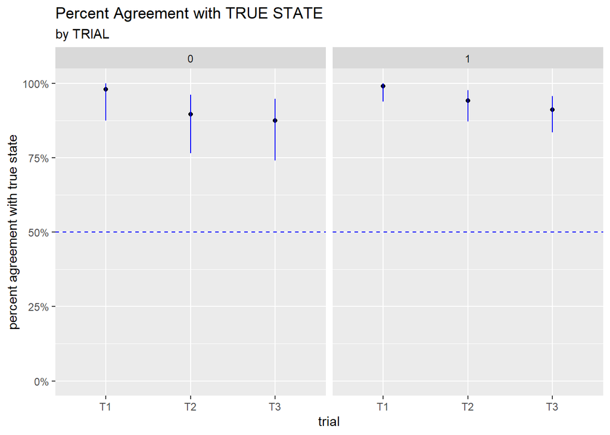

```r
# plot data
d2_summary_bytrial %>%
  ggplot(aes(x = trial, y = estimate)) +
  geom_point() +
  geom_hline(yintercept = 0.5, linetype = 2, color = 'blue') +
  geom_segment(aes(x = trial, xend = trial, y = conf.low, yend = conf.high, color = cross50)) +
  ggtitle(label = "Percent Agreement with TRUE STATE",
          subtitle = "by TRIAL") +
  scale_y_continuous(labels = scales::percent, limits = c(0, 1)) +
  scale_color_manual(values=c("blue", "red", "#00B81F", "red")) +
  ylab("percent agreement with true state") +
  theme(legend.position='none') +
  facet_wrap(~ true_state) +
  NULL
```

# ANALYSIS - Confusion Matrix

## explore confusion matrix

```r
d2confusion <- d2 %>%
  select(true_state, trial_result) #%>%
  # mutate(true = ifelse(true_state == "conform", 1, 0),
  #        trial = ifelse(trial_result == "conform", 1, 0))
# code commented out depends on how true_state and trial_result are coded in data

# glimpse(d2confusion)
# pander(d2confusion)
```

```r
caret::confusionMatrix(data = as.factor(d2confusion$trial_result),
                       reference = as.factor(d2confusion$true_state),
                       positive = "1",
                       mode = "sens_spec")
```

```
## Confusion Matrix and Statistics
##
##           Reference
## Prediction   0   1
##          0 132  16
##          1  12 290
##
##                Accuracy : 0.9378
##                  95% CI : (0.9113, 0.9583)
##     No Information Rate : 0.68
##     P-Value [Acc > NIR] : <2e-16
##
##                   Kappa : 0.8581
##
##  Mcnemar's Test P-Value : 0.5708
##
##             Sensitivity : 0.9477
##             Specificity : 0.9167
##          Pos Pred Value : 0.9603
##          Neg Pred Value : 0.8919
##              Prevalence : 0.6800
##          Detection Rate : 0.6444
##    Detection Prevalence : 0.6711
##       Balanced Accuracy : 0.9322
##
##        'Positive' Class : 1
##
```

NOTES on Sensitivity, Specificity, Misclassification Rate

- Sensitivity: The “true positive rate” – the percentage of individuals the model correctly predicted would default.
- Specificity: The “true negative rate” – the percentage of individuals the model correctly predicted would not default.
- Total misclassification rate: The percentage of total incorrect classifications made by the model.

## using InformationValue package ———————————————

# calculate total misclassification error rate

# (misclass_error_all <- InformationValue::misClassError(d2confusion$true_state, d2confusion$trial_result))

# (correctclass_all <- 1 - misclass_error_all)

# # seems to be the same as “accuracy” from the confusion matrix output

# ANALYSIS - AIAG METHOD PCT EFFECTIVE SCORE

AIAG MSA Manual p. 127 to 132

## effectiveness metric

Method: + for each part and operator, create indictor that shows whether complete or incomplete agreement by appraiser across trials  
+ group_by(inspector, specimen)  
+ summarize(result_mean = mean(trial_result))

```r
# prep data
d_agree_effective <- d2 %>%
  group_by(inspector, specimen) %>%
  summarize(result_mean = mean(trial_result)) %>%
  mutate(full_agree = case_when(result_mean == 0 ~ 1,
                                result_mean == 1 ~ 1,
                                TRUE ~ 0))
```

```
## `summarise()` has regrouped the output.
## ℹ Summaries were computed grouped by inspector and specimen.
## ℹ Output is grouped by inspector.
## ℹ Use `summarise(.groups = "drop_last")` to silence this message.
## ℹ Use `summarise(.by = c(inspector, specimen))` for per-operation grouping
##   (`?dplyr::dplyr_by`) instead.
```

```r
# generate AIAG results from page 131
d_agree_effective %>%
  group_by(inspector) %>%
  summarize(mean_effective = mean(full_agree)) %>%
  pander()
```

| inspector | mean_effective |
| --- | --- |
| A | 0.84 |
| B | 0.9 |
| C | 0.8 |

## vs_reference metric

```r
d_agree_reference <- d2 %>%
  group_by(inspector, specimen) %>%
  summarize(result_mean = mean(trial_result),
            true_state_mean = mean(true_state)) %>%
  mutate(reference_agree = case_when(result_mean == true_state_mean ~ 1,
                                     TRUE ~ 0))
```

```
## `summarise()` has regrouped the output.
## ℹ Summaries were computed grouped by inspector and specimen.
## ℹ Output is grouped by inspector.
## ℹ Use `summarise(.groups = "drop_last")` to silence this message.
## ℹ Use `summarise(.by = c(inspector, specimen))` for per-operation grouping
##   (`?dplyr::dplyr_by`) instead.
```

```r
d_agree_reference %>%
  group_by(inspector) %>%
  summarize(mean_reference_agree = mean(reference_agree)) %>%
  pander()
```

| inspector | mean_reference_agree |
| --- | --- |
| A | 0.84 |
| B | 0.9 |
| C | 0.8 |